# Curso 7 Regression Models

## Introducción

En estadística, el análisis de la regresión es un proceso estadístico para estimar las relaciones entre variables. Incluye muchas técnicas para el modelado y análisis de diversas variables, cuando la atención se centra en la relación entre una variable dependiente (o Outcome o Variable de respuesta) y una o más variables independientes (o Covariables o Variables regresoras ).

Este curso cubre análisis de regresión, mínimos cuadrados e inferencia usando modelos de regresión. Los casos especiales de modelos de regresión ANOVA y ANCOVA también serán cubiertos. El análisis de los residuos y la variablidad también se investigará. Los modelos de regresión producen modelos muy facilmente interpretables, al contrario que los algoritmos de aprendizaje automático que muchas veces sacrifican interpretabilidad por un mejor rendimiento en la predicción. Esto por supuesto es el fin de toda estimación, sin embargo por simpleza e interpretabilidad deberíamos optar siempre en primer lugar por estos modelos de regresión.

Podemos clasificar los tipos de regresión según diversos criterios.

En primer lugar, en función del número de variables independientes:

```
Regresión simple: Cuando la variable Y depende únicamente de una única variable X.

Regresión múltiple: Cuando la variable Y depende de varias variables (X1, X2, ..., Xr)
```

En segundo lugar, en función del tipo de función f(X):

```
Regresión lineal: Cuando f(X) es una función lineal.

Regresión no lineal: Cuando f(X) no es una función lineal.
```

En tercer lugar, en función de la naturaleza de la relación que exista entre las dos variables:

```
La variable X puede ser la causa del valor de la variable Y.
```

Por ejemplo, en toxicología, si X = Dosis de la droga e Y = Mortalidad, la mortalidad se atribuye a la dosis administrada y no a otras causas.

```
Puede haber simplemente relación entre las dos variables.
```

Por ejemplo, en un estudio de medicina en que se estudian las variables X = Peso e Y = Altura de un grupo de individuos, puede haber relación entre las dos, aunque difícilmente una pueda considerarse causa de la otra.

## Concepto de Regresión lineal y mínimos cuadrados

Los modelos lineales, relaccionan una salida con un conjunto de predictores de interás usando asunciones lineales. Son un subconjunto de los modelos de regresión, que son la herramienta más importante herramienta de análisis estadístico para un científico de datos. Un modelo de regresión lineal por tanto tendrá siempre la siguiente forma.

Y = A + BX + u

Y= variable dependiente o endógena

X= variable independiente o explicativa

A, B = parámetros fijos y desconocidos

Notación

- letras normales (i.e. $X$, $Y$) = se usan para representar variables **observadas**
- La letras griegas (i.e. $\mu$, $\sigma$) = se usan para representar variables **desconocidas** y que queremos estimar como la media o varianza de la población
- $X_1, X_2, \ldots, X_n$ describe $n$ puntos de datos
- $\bar X$, $\bar Y$ = medias observadas de las variables aleatorias $X$ and $Y$
- $\hat \beta_0$, $\hat \beta_1$ = estimaciones de los valores reales $\beta_0$ and $\beta_1$

Media de la muestra

- **Media de la muestra** se define como
  $$\bar X = \frac{1}{n}\sum_{i=1}^n X_i$$
- **centrar** la varible aleatoria es restar a todos sus valores la media de la muestra, por lo que tras el proceso la curva se centrará en el origen
  $$\tilde X_i = X_i - \bar X$$
  - mean of $\tilde X_i$ = 0

Desviación estándar y varianza

- **varianza** se define como
  $$S^2 = \frac{1}{n-1} \sum_{i=1}^n (X_i - \bar X)^2
  = \frac{1}{n-1} \left( \sum_{i=1}^n X_i^2 - n \bar X ^ 2 \right)
  \Leftarrow \mbox{shortcut for calculation}$$
- **desviación estándar** se define como $S = \sqrt{S^2}$
  - Al haber realizado la raiz cuadrada de la varianza, tenemos la desviación estándar en las mismas unidades que los datos
- **escalar** las variables aleatorias es dividir todos sus valores por la desviación estándar $X_i / S$
  - standard deviation of $X_i / S$ = 1

Normalizar

- **Normalizar** una variable aleatoria es centrarla y escalarla
  $$Z_i = \frac{X_i - \bar X}{s}$$
  - empirical mean = 0, empirical standard deviation = 1
  - Conseguimos que la distribución esté siempre centrada en 0 y que los datos muestren que están a unidades = # desviaciones estándar de la media original
    - *Ejemplo*: $Z_1 = 2$ significaría que punto Z está a 2 desviaciones estándar más allá de la media original

**LA NORMALIZACIÓN PERMITE COMPARAR DATOS NO COMPARABLES INCLUSO QUE TENGAN DISTINTAS UNIDADES**

Covarianza y Correlación

- Tenemos $(X_i, Y_i)$ = como pareja de datos
- **covarianza** se define como
  $$Cov(X, Y) = \frac{1}{n-1}\sum_{i=1}^n (X_i - \bar X) (Y_i - \bar Y) = \frac{1}{n-1}\left( \sum_{i=1}^n X_i Y_i - n \bar X \bar Y\right)$$
  - tiene como unidades $X \veces$ unidades de $Y$
- **correlación** se define como
  $$Cor(X, Y) = \frac{Cov(X, Y)}{S_x S_y}$$
  donde $S_x$ y $S_y$ son la estimación de las desviaciones estándar para las observaciones de $X$ y de $Y$ respectivamente.
  - El valor es efectivamente la covarianza estandarizada en una cantidad sin unidades
  - $Cor(X, Y) = Cor(Y, X)$
  - $-1 \leq Cor(X, Y) \leq 1$
  - $Cor(X,Y) = 1$ and $Cor(X, Y) = -1$ sólo cuando las observaciones $X$ o $Y$ caen perfectamente en una linea de pendiente positiva y negativa respectivamente
  - $Cor(X, Y)$ mide la fortaleza de la relación lineal entre $X$ e $Y$, con una relacción mucho más fuerte cada vez que $Cor(X,Y)$ se acerca a -1 o 1
  - $Cor(X, Y) = 0$ implica que no hay relación lineal.

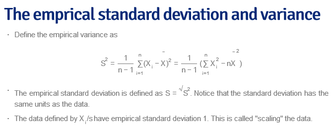

qownnotes-media-dXspNO

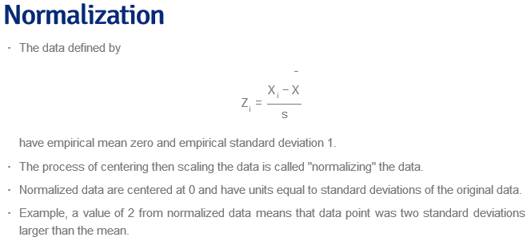

qownnotes-media-CwzJNE

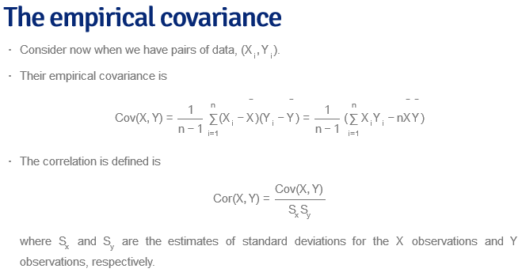

qownnotes-media-OXitOI

Galton intentaba inferir la altura de los hijos a partir de la altura de los padres.

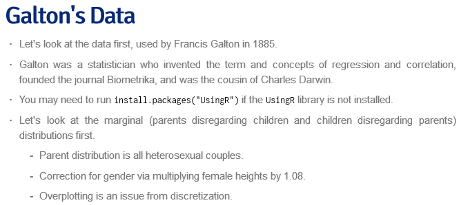

qownnotes-media-TlRIOL

```
{r galton,fig.height=3.5,fig.width=8}
library(UsingR); data(galton); library(reshape); long <- melt(galton)
g <- ggplot(long, aes(x = value, fill = variable))
g <- g + geom_histogram(colour = "black", binwidth=1)
g <- g + facet_grid(. ~ variable)
g
```

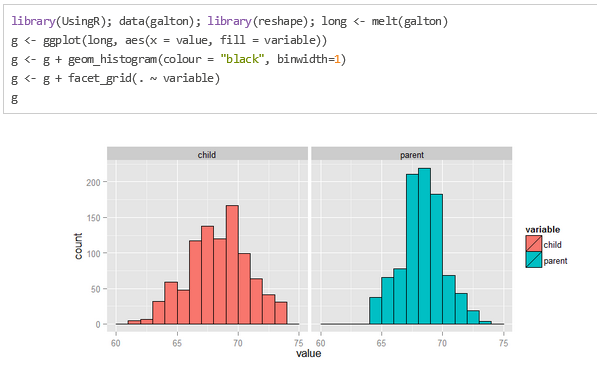

qownnotes-media-SqyrfP

Antes de ponernos a ver si podemos inferir la altura de los hijos por la altura de los padres a través del método de los mínimos cuadrados, explicaremos que el mínimo cuadrado es el valor mínimo de cada resta de un valor menos la media, todo ello al cuadrado.

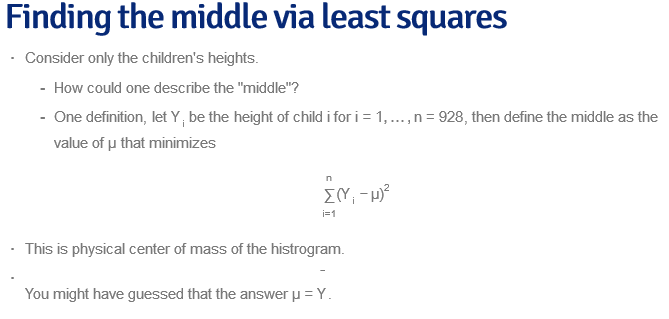

qownnotes-media-ndPBIN

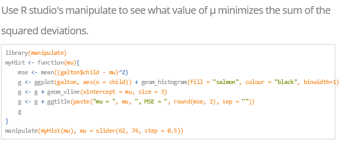

qownnotes-media-sjtBnE

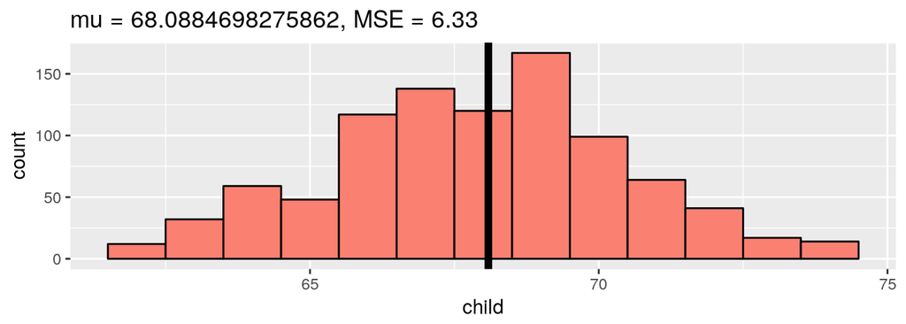

```r
# load necessary packages/install if needed
library(ggplot2); library(UsingR); data(galton)
# function to plot the histograms
myHist <- function(mu){
    # calculate the mean squares
    mse <- mean((galton$child - mu)^2)
    # plot histogram
    g <- ggplot(galton, aes(x = child)) + geom_histogram(fill = "salmon",
        colour = "black", binwidth=1)
    # add vertical line marking the center value mu
    g <- g + geom_vline(xintercept = mu, size = 2)
    g <- g + ggtitle(paste("mu = ", mu, ", MSE = ", round(mse, 2), sep = ""))
    g
}
# manipulate allows the user to change the variable mu to see how the mean squares changes
#   library(manipulate); manipulate(myHist(mu), mu = slider(62, 74, step = 0.5))]
# plot the correct graph
myHist(mean(galton$child))
```

El resultado como podemos observar es que la media (lógicamente) es el valor que minimiza al máximo el valor del mínimo cuadrado, si elegimos otro valor como media el mse ya no será el mínimo.

Una vez sabemos el valor de mse, vamos a mostrar un gráfico de 928 puntos con las alturas de los padres y los hijos emparejados. Las alturas de las mujeres han sido ajustadas a 1.08 respecto a los hombre para poder hacer la media. En el plot usamos la función jitter para que no se superpongan mucho los valores coincidentes.

```
{r,dependson="galton",fig.height=4,fig.width=4, fig.align='center'}
ggplot(galton, aes(x = parent, y = jitter(child))) + geom_point(shape=1)
```

[figure not shown]

qownnotes-media-BUMWUG

Ahora lo que haremos será añadir una linea al gráfico de color azul. Esta línea representa la mínima variación de los datos alrededor de él. Si la pendiente de la recta es mayor que cero significa que la altura de los padres afecta a la altura de los hijos.

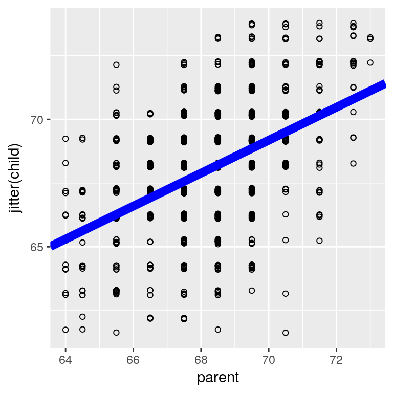

La pendiente de la recta es la estimación del coeficiente, o multiplicador de los padres, la variable independiente de nuestros datos. Con summary se puede ver la pendiente de la recta de regresión:

> regrline <- lm(child ~ parent,galton)

> summary(regrline)

Call: lm(formula = child ~ parent, data = galton)

Residuals: Min 1Q Median 3Q Max -7.8050 -1.3661 0.0487 1.6339 5.9264

Coefficients: Estimate Std. Error t value Pr(>|t|)  
(Intercept) 23.94153 2.81088 8.517 <2e-16

parent 0.64629 0.04114 15.711 <2e-16

Residual standard error: 2.239 on 926 degrees of freedom Multiple R-squared: 0.2105, Adjusted R-squared: 0.2096 F-statistic: 246.8 on 1 and 926 DF, p-value: < 2.2e-16

Vamos a añadir ahora dos líneas azules para indicar las medias de las alturas de los padres y de los hijos . Cabe destacar que ambas líneas se cruzan en el mismo punto, justo donde está el punto medio de la recta.

La pendiente de la curva roja muestra cuánto cambia en la dirección vertical en un cambio de la dirección horizontal, vemos que padres que están 1 pulgada por encima de la media suelen tener hijos que sólo están a 0.65 pulgadas de la media, el triángulo verde indica este punto.

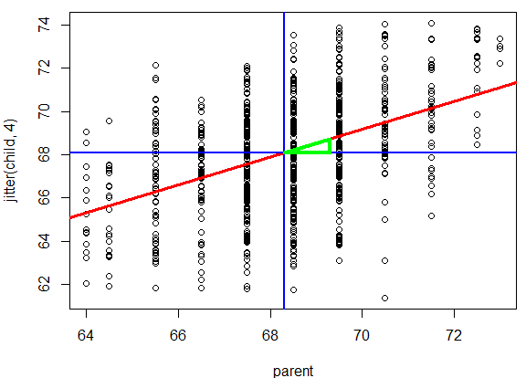

qownnotes-media-DBHmup

## Concepto de Residuos

- Residuo, $e_i$ = diferencia entre la salida observada y la que se ha estimado
  $$e_i = Y_i - \hat Y_i$$
  - También, distancia vertical entre el dato observado y la linea de regresión
  - Los mínimos cuadrados minimizan $\sum_{i=1}^n e_i^2$
- $e_i$ puede ser interpretado como el estimador del error de regresión, $\epsilon_i$
- $e_i$ también puede ser interpretado como la salida ($Y$) con asociación lineal del predictor ($X$) eliminada
  - o, “Y ajustada a X”
- $E[e_i] = 0$ $\rightarrow$ esto es porque la media de los residuos se espera que sea 0 (se asume distribución gaussiana)
  - Esta distribución de Gauss implica que el error **NO** está en correlación con ningún predictor
  - `mean(fitModel$residuals)` = devuelve la media de los residuos $\rightarrow$ debe ser igual a 0
  - `cov(fit$residuals, predictors)` = devuelve la covarianza (mide correlación) entre residuos y predictores $\rightarrow$ debe ser igual a 0
- $\sum_{i=1}^n e_i = 0$ (si el interceptor está incluido) and $\sum_{i=1}^n e_i X_i = 0$ (si una variable regresora $X_i$ está incluida)
- para modelos de regresión lineal estándar
  - positive residuals = por encima de la linea
  - negative residuals = por debajo
- Los residuos al ponerser en gráfica puden destacar una pobre convergencia del modelo

A continuación hay algunos ejemplos de cómo calcular los residuos, las distancias entre las alturas reales de los hijos y la estimada dada la línea de regresión. Como todas las líneas, está caracterizada por dos parámetros, una pendiente y un intercept, usaremos los mínimos cuadrados para proporcionar dos ecuaciones en dos datos desconocidos, de manera que podamos resolver estos dos parámetros

…

|====== | 6%

…

|========== | 9%

We’ll demonstrate these concepts now. First regenerate the regression line and call it fit. Use the R function lm. Recall that by default its first argument is a formula such as “child ~ parent” and its second is the dataset, in this case galton.

> lm(child ~ parent,galton)

Call: lm(formula = child ~ parent, data = galton)

Coefficients: (Intercept) parent  
23.9415 0.6463

You seem to have misspelled the model’s name. I was expecting fit but you apparently typed .

You’re close…I can feel it! Try it again. Or, type info() for more options.

Type “fit <- lm(child ~ parent, galton)” at the R prompt.

> fit <- lm(child ~ parent,galton)

You are really on a roll!

|============= | 12%

Now we’ll examine fit to see its slope and intercept. The residuals we’re interested in are stored in the 928-long vector fit$residuals. If you type fit$residuals you’ll see a lot of numbers scroll by which isn’t very useful; however if you type “summary(fit)” you will see a more concise display of the regression data. Do this now.

> summary(fit)

Call: lm(formula = child ~ parent, data = galton)

Residuals: Min 1Q Median 3Q Max -7.8050 -1.3661 0.0487 1.6339 5.9264

Coefficients: Estimate Std. Error t value Pr(>|t|)  
(Intercept) 23.94153 2.81088 8.517 <2e-16 ***

parent 0.64629 0.04114 15.711 <2e-16

|========================== | 25%

…

|============================= | 28%

Let “mch” represent the mean of the galton childrens’ heights and “mph” the mean of the galton parents’ heights. Let “ic” and “slope” represent the intercept and slope of the regression line respectively. As shown in the slides and past lessons, the point (mph,mch) lies on the regression line. This means

1: I haven’t the slightest idea. 2: mch = ic + slope*mph 3: mph = ic + slope*mch

Selection: 3

One more time. You can do it!

A line is the set of all points (x,y) satisfying the equation y = mx + b, where m is the slope of the line and b is its intercept. Remember that the point (mph,mch) lies on the regression line with intercept ic and slope “slope”.

1: mph = ic + slope*mch 2: I haven’t the slightest idea. 3: mch = ic + slope*mph

Selection: 3

You got it right!

|================================ | 31%

The function sqe calculates the sum of the squared residuals, the differences between the actual children’s heights and the estimated heights specified by the line defined by the given parameters (slope and intercept). R provides the function deviance to do exactly this using a fitted model (e.g., fit) as its argument. However, we provide sqe because we’ll use it to test regression lines different from fit.

…

|==================================== | 34%

We’ll see that when we vary or tweak the slope and intercept values of the regression line which are stored in fit$coef, the resulting squared residuals are approximately equal to the sum of two sums of squares - that of the original regression residuals and that of the tweaks themselves. More precisely, up to numerical error,

…

|======================================= | 38%

sqe(ols.slope+sl,ols.intercept+ic) == deviance(fit) + sum(est(sl,ic)^2 )

…

|========================================== | 41%

Equivalently, sqe(ols.slope+sl,ols.intercept+ic) == sqe(ols.slope, ols.intercept) + sum(est(sl,ic)^2 )

…

|============================================== | 44%

The left side of the equation represents the squared residuals of a new line, the “tweaked” regression line. The terms “sl” and “ic” represent the variations in the slope and intercept respectively. The right side has two terms. The first represents the squared residuals of the original regression line and the second is the sum of squares of the variations themselves.

…

|================================================= | 47%

We’ll demonstrate this now. First extract the intercept from fit$coef and put it in a variable called ols.ic . The intercept is the first element in the fit$coef vector, that is fit$coef[1].

> ols.ic <- fit$coef[1]

You are doing so well!

|==================================================== | 50%

Now extract the slope from fit$coef and put it in the variable ols.slope; the slope is the second element in the fit$coef vector, fit$coef[2].

> ols.slope <- fit$coef[2]

You are doing so well!

|======================================================= | 53%

…

|========================================================== | 56%

Subtract the right side, the vector rhs, from the left, the vector lhs, to see the relationship between them. You should get a vector of very small, almost 0, numbers.

> rhs -lhs [1] -1.264198e-09 -2.527486e-09 -3.801688e-09 1.261469e-09 2.522938e-09 3.767127e-09

Almost! Try again. Or, type info() for more options.

Type “lhs-rhs” at the R prompt.

> lhs-rhs [1] 1.264198e-09 2.527486e-09 3.801688e-09 -1.261469e-09 -2.522938e-09 -3.767127e-09

That’s correct!

|============================================================== | 59%

You could also use the R function all.equal with lhs and rhs as arguments to test for equality. Try it now.

> all.equal(lhs,rhs) [1] TRUE

You nailed it! Good job!

|================================================================= | 62%

Now we’ll show that the variance in the children’s heights is the sum of the variance in the OLS estimates and the variance in the OLS residuals. First use the R function var to calculate the variance in the children’s heights and store it in the variable varChild.

> varchild <- var(galton$child)

Keep trying! Or, type info() for more options.

Type “varChild <- var(galton$child)” at the R prompt.

> varChild <- var(galton$child)

That’s the answer I was looking for.

|==================================================================== | 66%

Remember that we’ve calculated the residuals and they’re stored in fit$residuals. Use the R function var to calculate the variance in these residuals now and store it in the variable varRes.

> varRes <- var(fit$residuals)

That’s the answer I was looking for.

|======================================================================== | 69%

Recall that the function “est” calculates the estimates (y-coordinates) of values along the regression line defined by the variables “ols.slope” and “ols.ic”. Compute the variance in the estimates and store it in the variable varEst.

> varEst(est(slope = ols.slope,intercept = ols.ic)) Error: could not find function “varEst” varEST <- var(est(slope = ols.slope,intercept = ols.ic))

You’re close…I can feel it! Try it again. Or, type info() for more options.

Type “varEst <- var(est(ols.slope, ols.ic))” at the R prompt.

> varEst <- var(est(ols.slope, ols.ic))

That’s correct!

|=========================================================================== | 72%

Now use the function all.equal to compare varChild and the sum of varRes and varEst.

> all.equal(varChild,sum(varRes,varEst)) [1] TRUE

Give it another try. Or, type info() for more options.

Type “all.equal(varChild,varEst+varRes)” at the R prompt.

> all.equal(varChild,varEst+varRes) [1] TRUE

You’re the best!

|============================================================================== | 75%

Since variances are sums of squares (and hence always positive), this equation which we’ve just demonstrated, var(data)=var(estimate)+var(residuals), shows that the variance of the estimate is ALWAYS less than the variance of the data.

…

|================================================================================= | 78%

Since var(data)=var(estimate)+var(residuals) and variances are always positive, the variance of residuals

1: is less than the variance of data 2: is unknown without actual data 3: is greater than the variance of data

Selection: 1

You are amazing!

|==================================================================================== | 81%

The two properties of the residuals we’ve emphasized here can be applied to datasets which have multiple predictors. In this lesson we’ve loaded the dataset attenu which gives data for 23 earthquakes in California. Accelerations are estimated based on two predictors, distance and magnitude.

…

|======================================================================================== | 84%

Generate the regression line for this data. Type efit <- lm(accel ~ mag+dist, attenu) at the R prompt.

> efit <- lm(accel ~ mag+dist, attenu)

That’s correct!

|=========================================================================================== | 88%

Verify the mean of the residuals is 0.

> mean(efit$residuals) [1] -1.785061e-18

Nice work!

|============================================================================================== | 91%

Using the R function cov verify the residuals are uncorrelated with the magnitude predictor, attenu$mag.

That’s not the answer I was looking for, but try again. Or, type info() for more options.

Type “cov(efit$residuals, attenu$mag)” at the R prompt.

> cov(efit$residuals, attenu$mag) [1] 5.338694e-17

Your dedication is inspiring!

|================================================================================================== | 94%

Using the R function cov verify the residuals are uncorrelated with the distance predictor, attenu$dist.

> cov(efit$residuals, attenu$dist) [1] 5.253433e-16

## Concepto de estimación por mínimos cuadrados

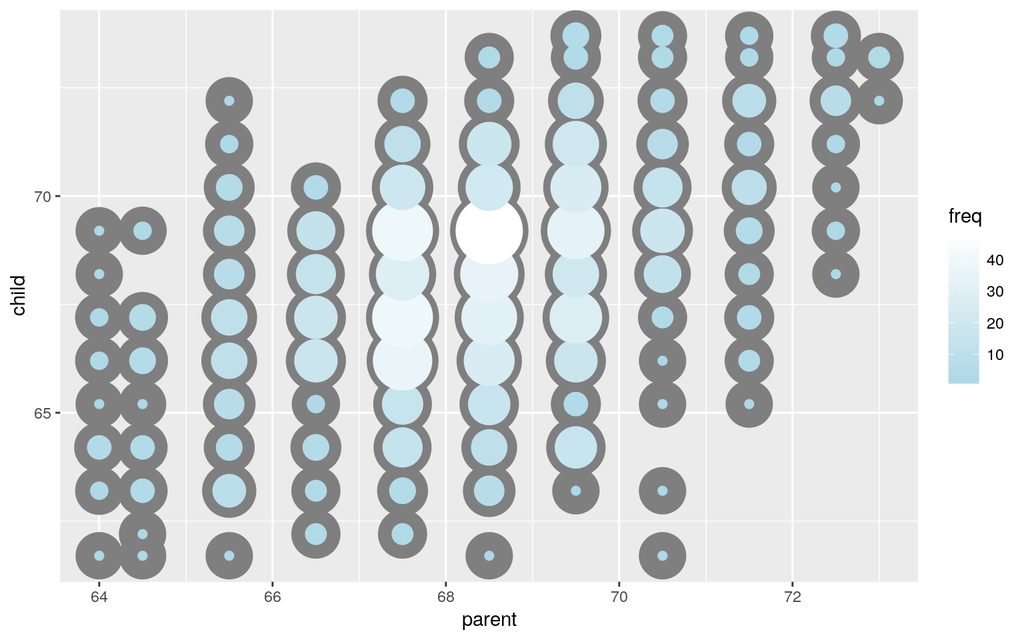

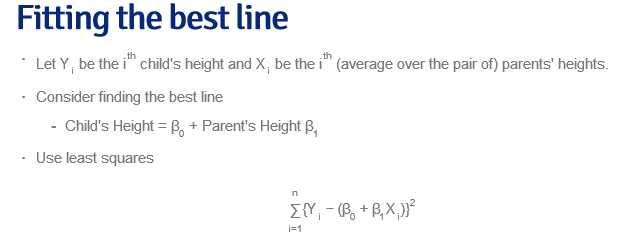

qownnotes-media-UYlNgi

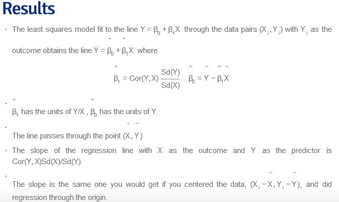

qownnotes-media-gaybyM

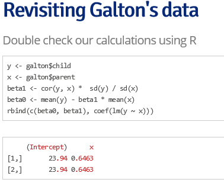

qownnotes-media-BpebuK

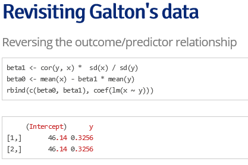

qownnotes-media-kWwUpE

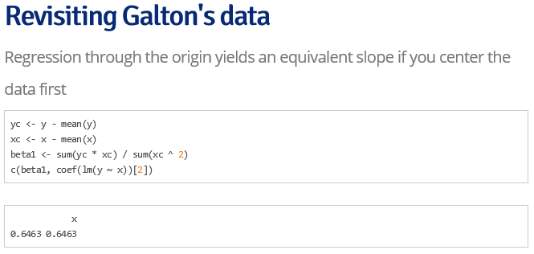

qownnotes-media-nBqHaI

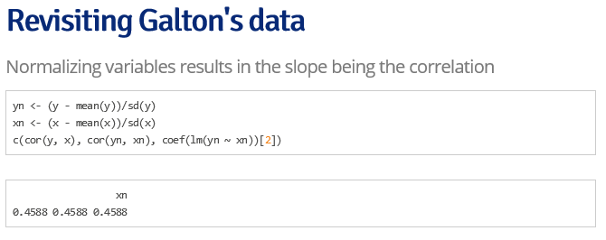

qownnotes-media-CmQKYz

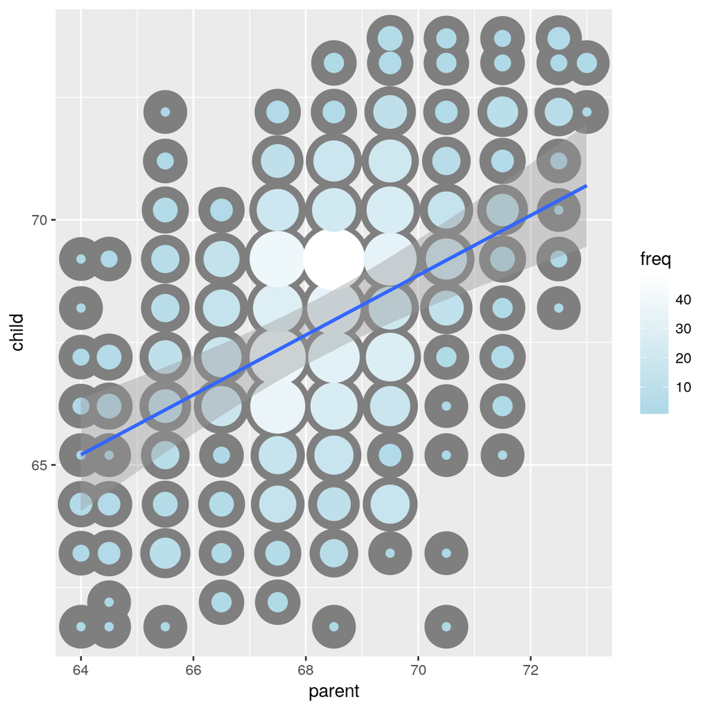

Como podemos ver, la linea de regresión resume la relación entre la altura de los padres (predictor) y la altura de los hijos (outcome)

Ejercicios

We learned in the last lesson that the regression line is the line through the data which has the minimum (least) squared “error”, the vertical distance between the 928 actual children’s heights and the heights predicted by the line. Squaring the distances ensures that data points above and below the line are treated the same. This method of choosing the ‘best’ regression line (or ‘fitting’ a line to the data) is known as ordinary least squares.

As shown in the slides, the slope of the regression line is the correlation between the two sets of heights multiplied by the ratio of the standard deviations (childrens’ to parents’ or outcomes to predictors).

…

|================================= | 32%

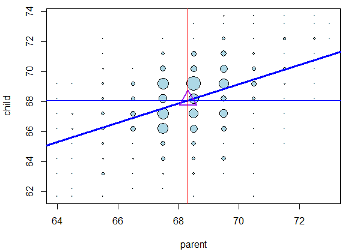

qownnotes-media-yULohl

Now you can actually play with the code to use R’s manipulate function and find the minimum squared error. You can adjust the slider with the left mouse button or use the right and left arrow keys to see how changing the slope (beta) affects the mean squared error (mse). If the slider disappears you can call it back by clicking on the little gear in the upper left corner of the plot window.

|================================================= | 47%

Which value of the slope minimizes the mean squared error?

1: .64 2: .44 3: 5 4: .70

Great job!

|======================================================= | 53%

What was the minimum mse?

1: .64 2: .66 3: 5.0 4: 44

Selection: 2

You’re close…I can feel it! Try it again.

You don’t want an error that’s too big or too small.

1: .64 2: 44 3: .66 4: 5.0

Selection: 4

Nice work!

|============================================================ | 58%

Recall that you normalize data by subtracting its mean and dividing by its standard deviation. We’ve done this for the galton child and parent data for you. We’ve stored these normalized values in two vectors, gpa_nor and gch_nor, the normalized galton parent and child data.

…

|================================================================== | 63%

Use R’s function “cor” to compute the correlation between these normalized data sets.

> cor(gch_nor,gpa_nor) [1] 0.4587624

Your dedication is inspiring!

|======================================================================= | 68%

How does this correlation relate to the correlation of the unnormalized data?

1: It is the same. 2: It is bigger. 3: It is smaller.

Selection: 1

You’re the best!

|============================================================================= | 74%

Use R’s function “lm” to generate the regression line using this normalized data. Store it in a variable called l_nor. Use the parents’ heights as the predictors (independent variable) and the childrens’ as the predicted (dependent). Remember, ‘lm’ needs a formula of the form dependent ~ independent. Since we’ve created the data vectors for you there’s no need to provide a second “data” argument as you have previously.

> l_nor <- lm(gch_nor~gpa_nor)

You are amazing!

|================================================================================== | 79%

What is the slope of this line?

1: I have no idea 2: 1. 3: The correlation of the 2 data sets

Selection: 3

All that practice is paying off!

|======================================================================================== | 84%

If you swapped the outcome (Y) and predictor (X) of your original (unnormalized) data, (for example, used childrens’ heights to predict their parents), what would the slope of the new regression line be?

1: the same as the original 2: I have no idea 3: 1. 4: correlation(X,Y) * sd(X)/sd(Y)

Selection: 4

Excellent job!

|============================================================================================= | 89%

We’ll close with a final display of source code from the slides. It plots the galton data with three regression lines, the original in red with the children as the outcome, a new blue line with the parents’ as outcome and childrens’ as predictor, and a black line with the slope scaled so it equals the ratio of the standard deviations.

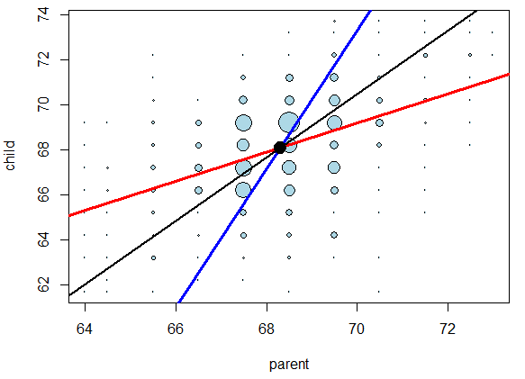

qownnotes-media-LnkyEN

## TEST 1

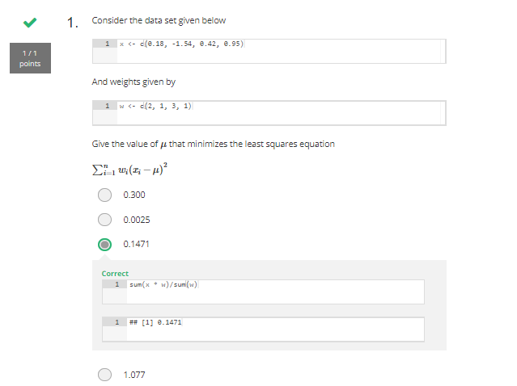

qownnotes-media-iTHEhs

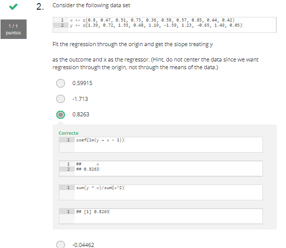

qownnotes-media-bTsdUo

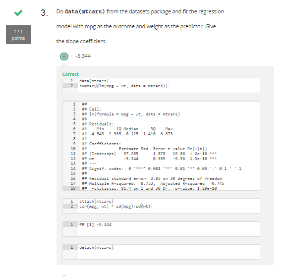

qownnotes-media-egzUYt

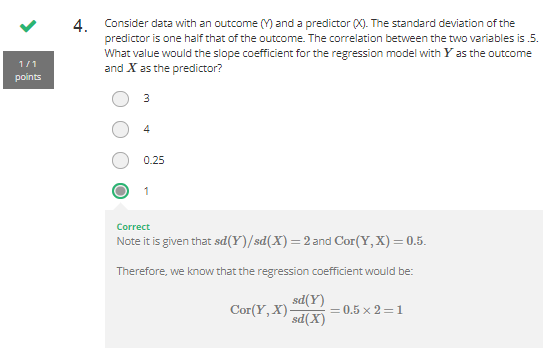

qownnotes-media-jSoMNj

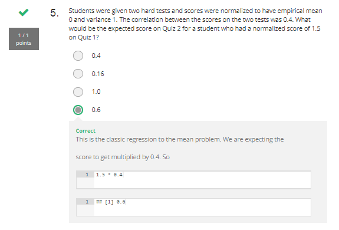

qownnotes-media-rGCbis

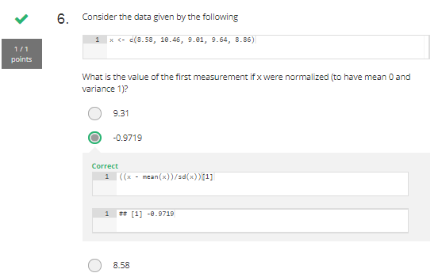

qownnotes-media-CMiOzc

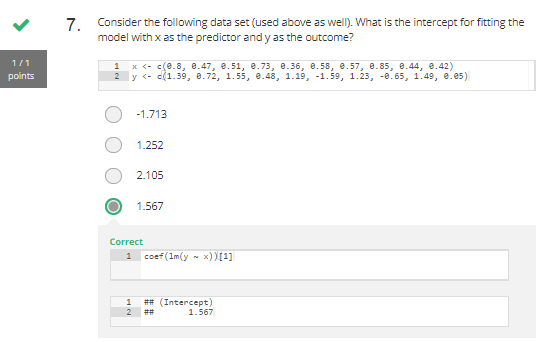

qownnotes-media-rPUzYm

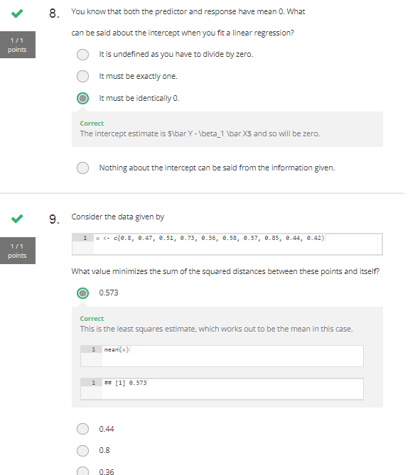

qownnotes-media-UQjwkz

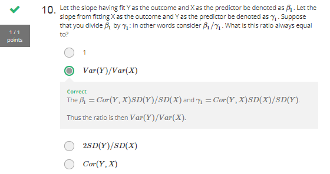

qownnotes-media-elvFIV